# Lab4a

## Getting set up: downloading packages, libraries and the John Hopkins Data.

```r
install.packages("tidyverse")
library(tidyverse)
library(DT)
```

```r
report_03_11_2020 <- read_csv(url("https://raw.githubusercontent.com/CSSEGISandData/COVID-19/master/csse_covid_19_data/csse_covid_19_daily_reports/03-11-2020.csv")) %>%
rename(Country_Region = "Country/Region", Province_State = "Province/State")
report_09_13_2020 <- read_csv(url("https://raw.githubusercontent.com/CSSEGISandData/COVID-19/master/csse_covid_19_data/csse_covid_19_daily_reports/09-13-2020.csv"))
```

## 1. What are the differences between 3/13/2020, the Friday before spring break 2020 and yesterday 6 months later on 9/13/2020?

```r
str(report_03_11_2020)
```

```
## tibble [216 × 8] (S3: spec_tbl_df/tbl_df/tbl/data.frame)
##  $ Province_State: chr [1:216] "Hubei" NA NA NA ...
##  $ Country_Region: chr [1:216] "China" "Italy" "Iran" "Korea, South" ...
##  $ Last Update   : POSIXct[1:216], format: "2020-03-11 10:53:02" "2020-03-11 21:33:02" ...
##  $ Confirmed     : num [1:216] 67773 12462 9000 7755 2281 ...
##  $ Deaths        : num [1:216] 3046 827 354 60 48 ...
##  $ Recovered     : num [1:216] 49134 1045 2959 288 12 ...
##  $ Latitude      : num [1:216] 31 43 32 36 46.2 ...
##  $ Longitude     : num [1:216] 112.27 12 53 128 2.21 ...
##  - attr(*, "spec")=
##   .. cols(
##   ..   `Province/State` = col_character(),
##   ..   `Country/Region` = col_character(),
##   ..   `Last Update` = col_datetime(format = ""),
##   ..   Confirmed = col_double(),
##   ..   Deaths = col_double(),
##   ..   Recovered = col_double(),
##   ..   Latitude = col_double(),
##   ..   Longitude = col_double()
##   .. )
```

```r
str(report_09_13_2020)
```

```
## tibble [3,954 × 14] (S3: spec_tbl_df/tbl_df/tbl/data.frame)
##  $ FIPS               : num [1:3954] NA NA NA NA NA NA NA NA NA NA ...
##  $ Admin2             : chr [1:3954] NA NA NA NA ...
##  $ Province_State     : chr [1:3954] NA NA NA NA ...
##  $ Country_Region     : chr [1:3954] "Afghanistan" "Albania" "Algeria" "Andorra" ...
##  $ Last_Update        : POSIXct[1:3954], format: "2020-09-14 04:26:09" "2020-09-14 04:26:09" ...
##  $ Lat                : num [1:3954] 33.9 41.2 28 42.5 -11.2 ...
##  $ Long_              : num [1:3954] 67.71 20.17 1.66 1.52 17.87 ...
##  $ Confirmed          : num [1:3954] 38716 11353 48254 1344 3388 ...
##  $ Deaths             : num [1:3954] 1420 334 1612 53 134 ...
##  $ Recovered          : num [1:3954] 31638 6569 34037 943 1301 ...
##  $ Active             : num [1:3954] 5658 4450 12605 348 1953 ...
##  $ Combined_Key       : chr [1:3954] "Afghanistan" "Albania" "Algeria" "Andorra" ...
##  $ Incidence_Rate     : num [1:3954] 99.5 394.5 110 1739.5 10.3 ...
##  $ Case-Fatality_Ratio: num [1:3954] 3.67 2.94 3.34 3.94 3.96 ...
##  - attr(*, "spec")=
##   .. cols(
##   ..   FIPS = col_double(),
##   ..   Admin2 = col_character(),
##   ..   Province_State = col_character(),
##   ..   Country_Region = col_character(),
##   ..   Last_Update = col_datetime(format = ""),
##   ..   Lat = col_double(),
##   ..   Long_ = col_double(),
##   ..   Confirmed = col_double(),
##   ..   Deaths = col_double(),
##   ..   Recovered = col_double(),
##   ..   Active = col_double(),
##   ..   Combined_Key = col_character(),
##   ..   Incidence_Rate = col_double(),
##   ..   `Case-Fatality_Ratio` = col_double()
##   .. )
```

There are more column included in the 9/13/2020 data set, such as: FIPS, Admin2, Active, Combined_Key, Incidence_Rate and Case-Fatality_Ratio.

## 2. Make a data frame with the total counts for each country by tibble.

```r
report_March_country_total <- report_03_11_2020 %>%
  group_by(Country_Region) %>%
  summarise(Total_Confirmed = sum(Confirmed),
    Total_Deaths = sum(Deaths),
    Total_Recovered = sum(Recovered)
  )
report_Sept_country_total <- report_09_13_2020 %>%
  group_by(Country_Region) %>%
  summarise(Total_Confirmed = sum(Confirmed),
    Total_Deaths = sum(Deaths),
    Total_Recovered = sum(Recovered)
  )
datatable(report_March_country_total)
```

|  | Country_Region | Total_Confirmed | Total_Deaths | Total_Recovered |
| --- | --- | --- | --- | --- |
| 1 | Afghanistan | 7 | 0 | 0 |
| 2 | Albania | 12 | 1 | 0 |
| 3 | Algeria | 20 | 0 | 0 |
| 4 | Andorra | 1 | 0 | 0 |
| 5 | Argentina | 19 | 1 | 0 |
| 6 | Armenia | 1 | 0 | 0 |
| 7 | Australia | 128 | 3 | 21 |
| 8 | Austria | 246 | 0 | 4 |
| 9 | Azerbaijan | 11 | 0 | 3 |
| 10 | Bahrain | 195 | 0 | 35 |

[output cut: 106 more lines]

```r
datatable(report_Sept_country_total)
```

|  | Country_Region | Total_Confirmed | Total_Deaths | Total_Recovered |
| --- | --- | --- | --- | --- |
| 1 | Afghanistan | 38716 | 1420 | 31638 |
| 2 | Albania | 11353 | 334 | 6569 |
| 3 | Algeria | 48254 | 1612 | 34037 |
| 4 | Andorra | 1344 | 53 | 943 |
| 5 | Angola | 3388 | 134 | 1301 |
| 6 | Antigua and Barbuda | 95 | 3 | 91 |
| 7 | Argentina | 555537 | 11352 | 419513 |
| 8 | Armenia | 45862 | 916 | 41659 |
| 9 | Australia | 26692 | 816 | 23463 |
| 10 | Austria | 33159 | 756 | 26760 |

[output cut: 178 more lines]

## 3. To get counts for confirmed cases per U.S state use filter() to select US and group_by and summarize as above.

```r
report_March_US_conf <- report_03_11_2020 %>%
  filter(Country_Region == "US") %>%
  select(Province_State, Confirmed)

report_Sept_US_conf <- report_09_13_2020 %>%
  filter(Country_Region == "US") %>%
  group_by(Province_State) %>%
  summarize(Total_Confirmed = sum(Confirmed))
datatable(report_March_US_conf)
```

|  | Province_State | Confirmed |
| --- | --- | --- |
| 1 | Washington | 366 |
| 2 | New York | 220 |
| 3 | California | 177 |
| 4 | Massachusetts | 95 |
| 5 | Diamond Princess | 46 |
| 6 | Colorado | 34 |
| 7 | Florida | 28 |
| 8 | Illinois | 25 |
| 9 | Georgia | 23 |
| 10 | New Jersey | 23 |

[output cut: 42 more lines]

```r
datatable(report_Sept_US_conf)
```

|  | Province_State | Total_Confirmed |
| --- | --- | --- |
| 1 | Alabama | 138755 |
| 2 | Alaska | 6268 |
| 3 | Arizona | 208512 |
| 4 | Arkansas | 70219 |
| 5 | California | 761728 |
| 6 | Colorado | 61293 |
| 7 | Connecticut | 54326 |
| 8 | Delaware | 18849 |
| 9 | Diamond Princess | 49 |
| 10 | District of Columbia | 14592 |

[output cut: 48 more lines]

## 4. Use arrange_by() and slice() to get just the top 10 countries for Deaths.

```r
report_March_top10 <- report_March_country_total %>%
  select(Country_Region, Total_Deaths) %>%
  arrange(desc(Total_Deaths)) %>%
  slice(1:10)
report_Sept_top10 <- report_Sept_country_total %>%
  select(Country_Region, Total_Deaths) %>%
  arrange(desc(Total_Deaths)) %>%
  slice(1:10)
```

```r
datatable(report_March_top10)
```

|  | Country_Region | Total_Deaths |
| --- | --- | --- |
| 1 | China | 3161 |
| 2 | Italy | 827 |
| 3 | Iran | 354 |
| 4 | Korea, South | 60 |
| 5 | Spain | 54 |
| 6 | France | 48 |
| 7 | US | 36 |
| 8 | Japan | 15 |
| 9 | United Kingdom | 8 |
| 10 | Cruise Ship | 7 |

```r
datatable(report_Sept_top10)
```

|  | Country_Region | Total_Deaths |
| --- | --- | --- |
| 1 | US | 194071 |
| 2 | Brazil | 131625 |
| 3 | India | 78586 |
| 4 | Mexico | 70821 |
| 5 | United Kingdom | 41717 |
| 6 | Italy | 35610 |
| 7 | France | 30903 |
| 8 | Peru | 30526 |
| 9 | Spain | 29747 |
| 10 | Iran | 23157 |

## 5. Make plots using geom_point() of the (top) 10 countries with the confirmed cases and deaths (two separate graphs) on 3/12/2020 and 9/12/2020.

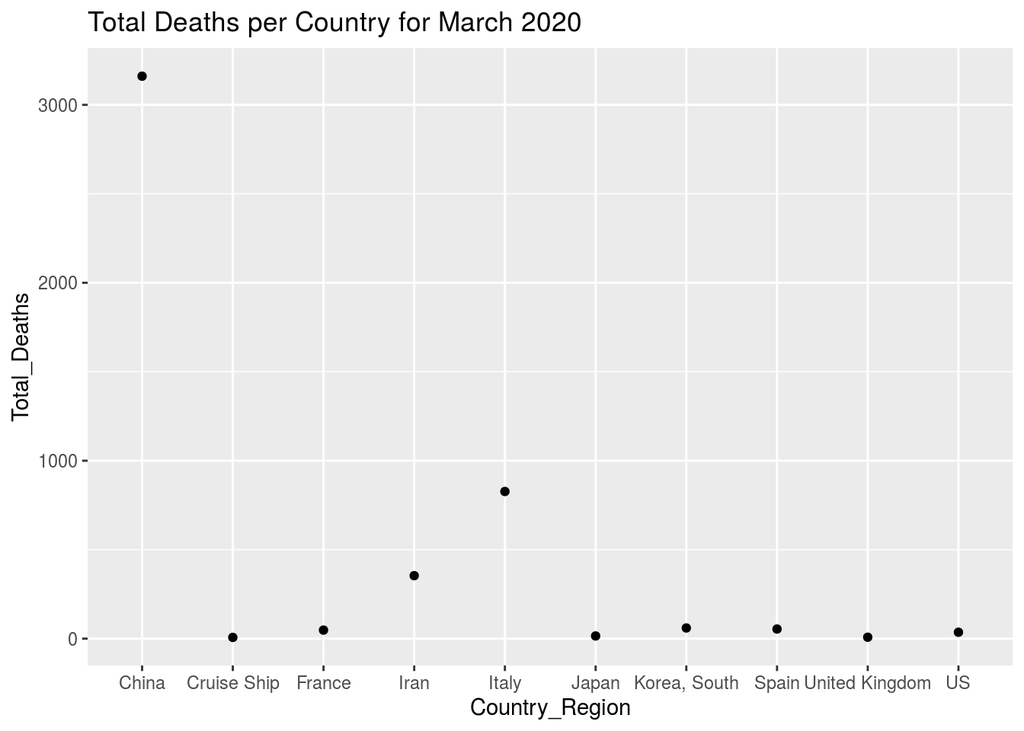

```r
March_death_plot <- ggplot(data = report_March_top10,
                       mapping = aes(x = Country_Region, y = Total_Deaths))
March_death_plot +
    geom_point() +
  ggtitle("Total Deaths per Country for March 2020")
```

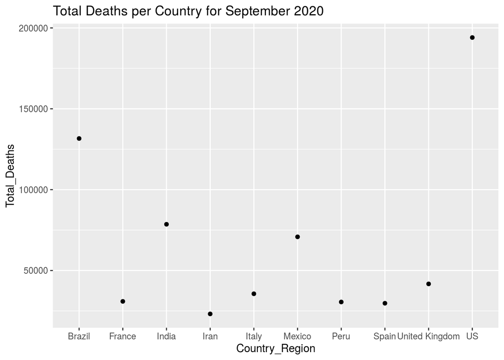

```r
Sept_death_plot <- ggplot(data = report_Sept_top10,
                       mapping = aes(x = Country_Region, y = Total_Deaths))
Sept_death_plot +
    geom_point() +
  ggtitle("Total Deaths per Country for September 2020")
```

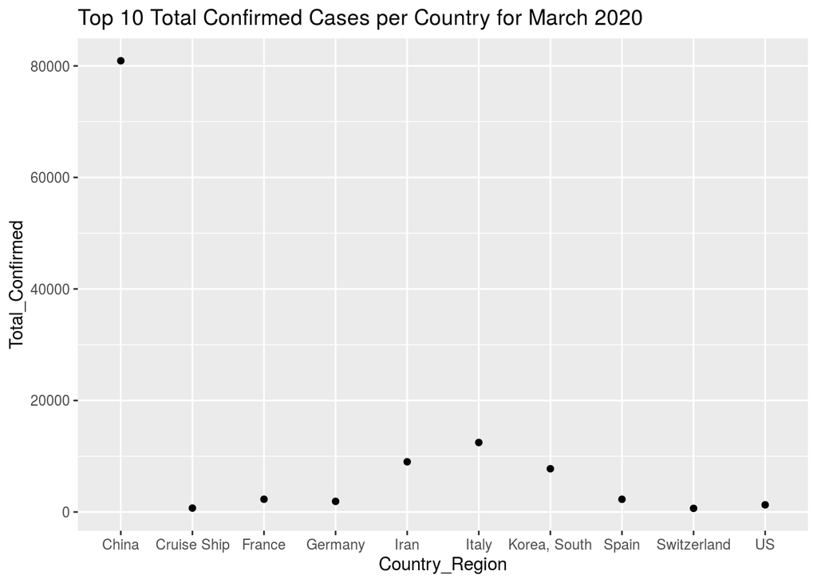

```r
report_March_top10_conf <- report_March_country_total %>%
  select(Country_Region, Total_Confirmed) %>%
  arrange(desc(Total_Confirmed)) %>%
  slice(1:10)
report_Sept_top10_conf <- report_Sept_country_total %>%
  select(Country_Region, Total_Confirmed) %>%
  arrange(desc(Total_Confirmed)) %>%
  slice(1:10)

March_conf_plot <- ggplot(data = report_March_top10_conf,
                       mapping = aes(x = Country_Region, y = Total_Confirmed))
March_conf_plot +
    geom_point() +
  ggtitle("Top 10 Total Confirmed Cases per Country for March 2020")
```

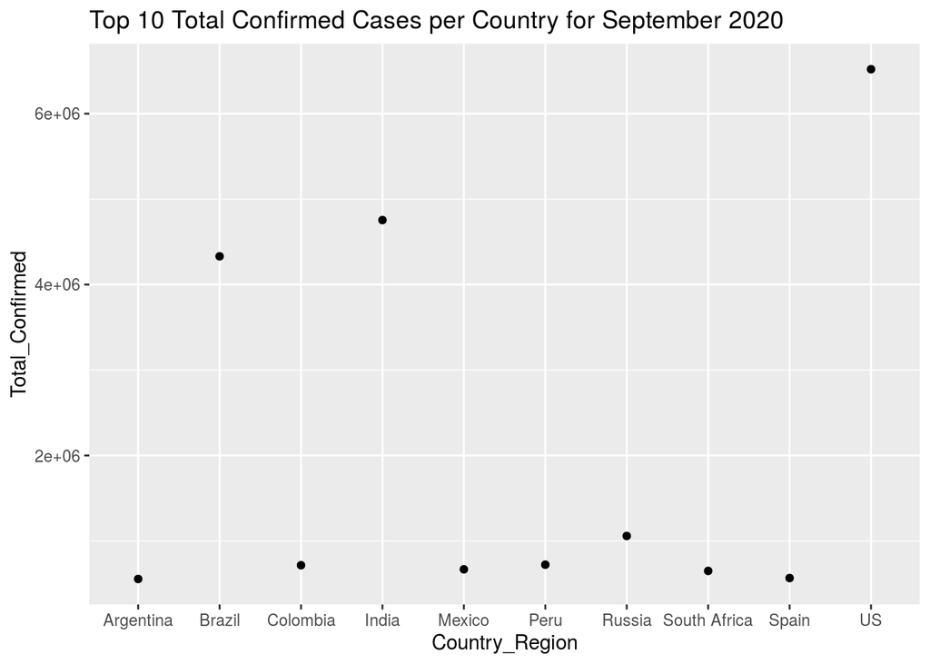

```r
Sept_conf_plot <- ggplot(data = report_Sept_top10_conf,
                       mapping = aes(x = Country_Region, y = Total_Confirmed))
Sept_conf_plot +
    geom_point() +
  ggtitle("Top 10 Total Confirmed Cases per Country for September 2020")
```

## 6. Make using geom_bar of the (top) 10 states with the most confirmed cases and deaths (two separate graphs) on 3/12/2020 and 9/12/2020.

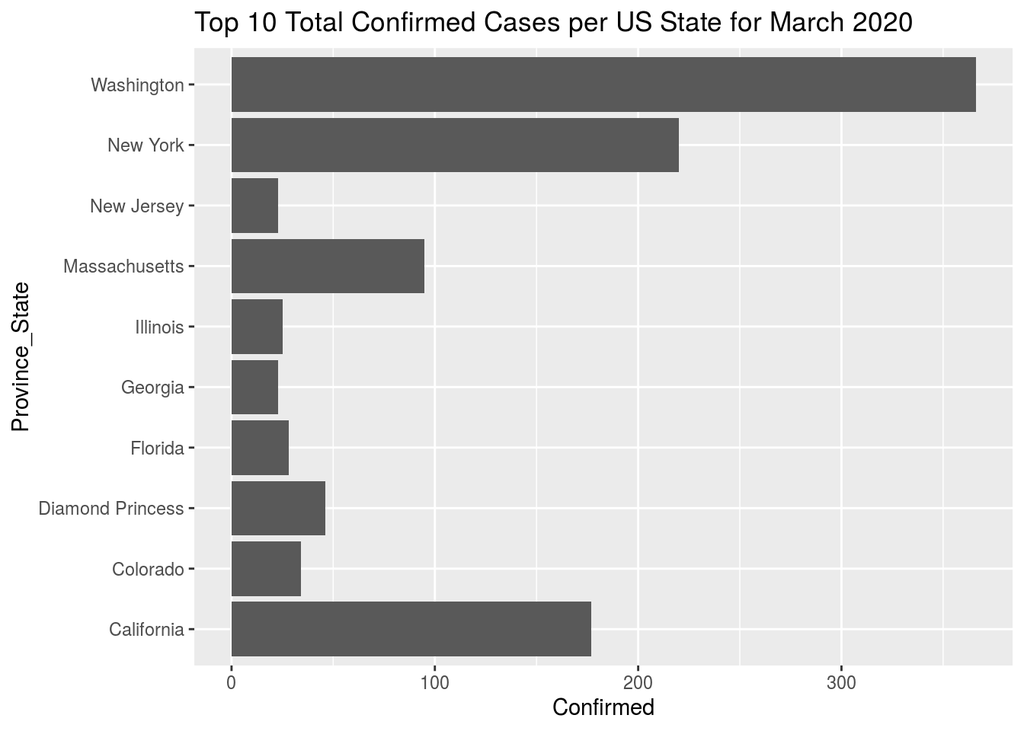

```r
report_March_top_US_conf <- report_March_US_conf %>%
  select(Province_State, Confirmed) %>%
  arrange(desc(Confirmed)) %>%
  slice(1:10)

ggplot(report_March_top_US_conf, aes(x = Confirmed, y = Province_State)) +
geom_bar(stat = 'identity') +
  ggtitle("Top 10 Total Confirmed Cases per US State for March 2020")
```

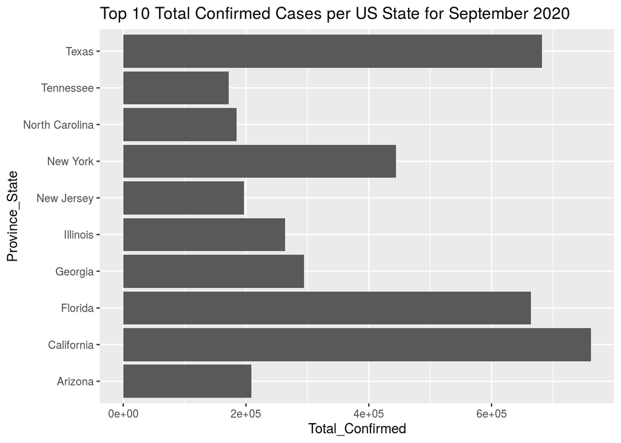

```r
report_Sept_top_US_conf <- report_Sept_US_conf %>%
  select(Province_State, Total_Confirmed) %>%
  arrange(desc(Total_Confirmed)) %>%
  slice(1:10)

ggplot(report_Sept_top_US_conf, aes(x = Total_Confirmed, y = Province_State)) +
geom_bar(stat = 'identity') +
  ggtitle("Top 10 Total Confirmed Cases per US State for September 2020")
```